# Model_Preparation_Challenge

##### Model Preparation Challenge

This is an assignment for my thinkful data science course - "Model_Preparation_Challenge" Raj Prasad May 2019

[html version](https://daddyprasad5.github.io/Model_Preparation_Challenge.html) - with all the code hidden away for a quick read

[jupyter notebook version](https://github.com/daddyprasad5/thinkful/blob/master/Model_Preparation_Challenge.ipynb) - with all the code exposed in an interactive notebook

My goal in this challenge is to identify features that could be used in a model to predict life-expectancy for a given country and year.

## Summary

I would begin my modeling using five features: the status of the country (developed vs developing) and the first four PCA components of 10 continuous dimensions (described below). The four PCA components capture nearly 80% of the variance in the 10 dimensions, and have correlation with life expectancy of .85, .05, .18 and .19 respectively. This approach captures much of the information in 11 dimensions, with the computational complexity of only 5 dimensions.

These are the candidate features and my recommendation to include the feature or not in first modeling attempts.

**candidate features that are recommended:**

**candidate features that are not recommended, and why each is excluded:**

Adult Mortality

- definition: Adult Mortality Rates of both sexes (probability of dying between 15 and 60 years per 1000 population)
- why excluded: Predicting life expectancy given death rates is hardly insightful.

infant deaths:

- definition: Number of Infant Deaths per 1000 population
- why excluded: Predicting life expectancy given death rates is hardly insightful.

under 5 deaths:

- definition: Number of under-five deaths per 1000 population
- why excluded: Predicting life expectancy given death rates is hardly insightful.

Measles

- definition: Measles - number of reported cases per 1000 population
- why excluded: low correlation with Life Expectancy

Thinness 1-19 years

- definition: Prevalence of thinness among children and adolescents for Age 10 to 19 (% )
- why excluded: extremely high correlation with another (included) candidate dimension.

GDP

- definition: Gross Domestic Product per capita (in USD)
- why excluded: Data is missing for a large percentage of countries.

Population

- definition: population of the country
- why excluded: Data is missing for a large percentage of countries.

The remainder of this analysis is broken into these parts:

- Data Cleansing
- Univariate analysis
- Bivariate analysis - correlation with Life Expectancy
- Feature selection

```python
#imports↔
```

```python
#data load↔
```

## Data Cleaning

### Missing Values

There are many missing values. I followed these steps to fill missing values:

1. I've first filled missing values with interpolation, with the data sequenced by country and then year. This filled a small percentage of the missing values.
2. The remaining missing values did not have data for that country & variable for the before / after years. The next best fill strategy was to fill with the mean for a given country across all years. This filled a small portion of the remaining missing values.
3. A large portion of all the missing values in the raw data still remained missing. These values are for countries with no data for the given variable across all years. Some variables had no data for a large percentage (>5%) of countries across all years:
- population (22%)
- GDP (14%)
- Income composition of resources (6%)
- Schooling (6%)
- Hepatitis B (5%)

I had several options for dealing with these missing values:

- *Drop the rows:* Dropping the rows that contain these nulls would drop a lot of countries entirely out of the analysis. Those countries do have a lot of meaningful data in other variables.
- *Fill with a mean or median across all countries for the given year:* Filling a large % of values could distort findings, especially in the case of GDP and Population.
- *Drop the columns:* Dropping the column entirely only makes sense if the other options would lead to distortions in the analysis.

I dropped the columns with the most missing data (GDP and population) from the analysis entirely, and filled the others with averages for each year across all the countries.

```python
#fix column headers↔
```

```python
#fill missing values↔
```

```python
#Dropping GDP and Pop, filling the remainder with annual average across all countries↔
```

### Outliers:

Extreme values can dramatically impact the analysis by, for example, pulling means far from the median or growing the standard deviations. In cases where there is likely measurement error, I've modified the observiations through winsorization. In cases where there are statistically extreme values but where I have no reason to suspect measurement error, I have prefered a log transformation, relying on winsorization only for variables with zero values.

Here I've outlined each concern by issue type, along with how I've altered the data to reduce the number and impact of outliers.

**Measurement errors:**

Issue: Infant mortality per thousand observations is far too high in many cases (e.g. greater than 1000).

Issue: Under-five deaths per 1000 births are far too high in many cases. the highest rate in 2017 per the world bank is 127 (Somalia).  
ACTION: I have windsorized on the high side.

**other extreme observations:** These are extreme values statistically, but I have no semantic reason to distrust the measurement.

Issue: a variable has just a few outliers (beyond 3 standard deviations) and they are just beyond that thresshold:

Action: Do nothing. Acknowledge the outliers but accept them as reasonable, actual observations that are unlikely to impact the analysis.

Issue: outliers on the high side, all values postive & non-zero:

Action: take the log of these measures

Issue: outliers on the low side, all values positive & non-zero:

- Polio
- Diptheria

Action: take the log.

Issue: Outliers high, and variable has negative or zero-values:

- Infant deaths
- Measles
- Under 5 deaths
- Percentage expenditure

Action: winsorize high

Issue: Outliers low and high, and variable has negative or zero-values:

- schooling

Action: winsorize low and high

Issue: Outliers low and high, and variable has negative or zero-values:

- income composition

Action: winsorize low

**Metadata likely inaccurate**

Issues:

Action: Assume that the metadata is incorrect and proceed.

### Other Data Quality Concers

**Unclear meaning:**

Issues:

- Percentage Expenditure is the ratio of total expenditure on health as a percentage of GDP per Capita. This is strange combination. It's not clear why one would not take the proporiton of two per capita measures or two total measures.
- Unclear what "income composition of resources" really means. The Kaggle metatdata is difficult to decipher: "Human Development Index in terms of income composition of resources (index ranging from 0 to 1"

Action: I will use these variables cautiously.

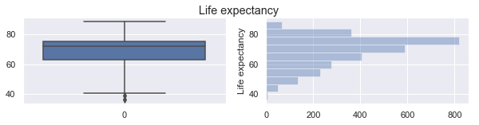

```
For column Life expectancy...
Number of outliers (up-side) is: 0 at threshold 3
Number of outliers (down-side) is: 2 at threshold 3
```

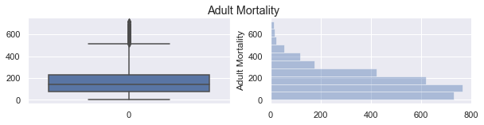

```
For column Adult Mortality...
Number of outliers (up-side) is: 40 at threshold 3
Number of outliers (down-side) is: 0 at threshold 3
```

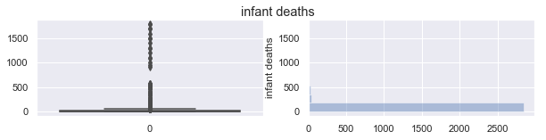

```
For column infant deaths...
Number of outliers (up-side) is: 37 at threshold 3
Number of outliers (down-side) is: 0 at threshold 3
```

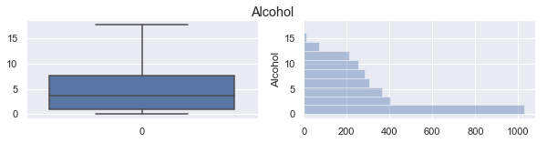

```
For column Alcohol...
Number of outliers (up-side) is: 3 at threshold 3
Number of outliers (down-side) is: 0 at threshold 3
```

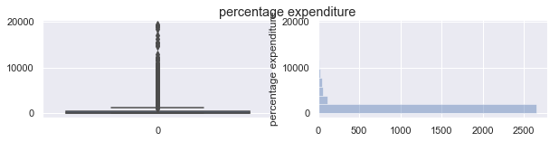

```
For column percentage expenditure...
Number of outliers (up-side) is: 84 at threshold 3
Number of outliers (down-side) is: 0 at threshold 3
```

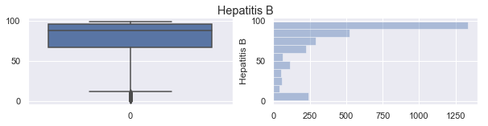

```
For column Hepatitis B...
Number of outliers (up-side) is: 0 at threshold 3
Number of outliers (down-side) is: 0 at threshold 3
```

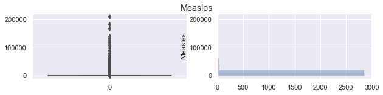

```
For column Measles...
Number of outliers (up-side) is: 48 at threshold 3
Number of outliers (down-side) is: 0 at threshold 3
```

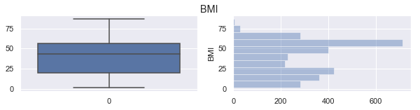

```
For column BMI...
Number of outliers (up-side) is: 0 at threshold 3
Number of outliers (down-side) is: 0 at threshold 3
```

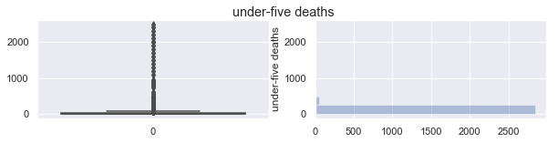

```
For column under-five deaths...
Number of outliers (up-side) is: 34 at threshold 3
Number of outliers (down-side) is: 0 at threshold 3
```

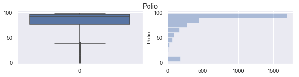

```
For column Polio...
Number of outliers (up-side) is: 0 at threshold 3
Number of outliers (down-side) is: 178 at threshold 3
```

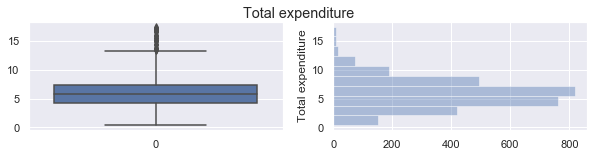

```
For column Total expenditure...
Number of outliers (up-side) is: 27 at threshold 3
Number of outliers (down-side) is: 0 at threshold 3
```

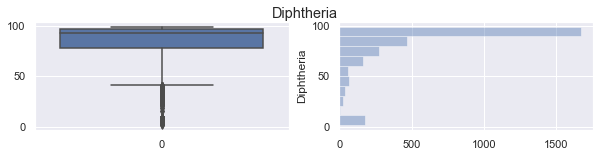

```
For column Diphtheria...
Number of outliers (up-side) is: 0 at threshold 3
Number of outliers (down-side) is: 176 at threshold 3
```

[5 more figures not shown]

```
For column Schooling...
Number of outliers (up-side) is: 0 at threshold 3
Number of outliers (down-side) is: 28 at threshold 3
```

```python
#find outliers↔
```

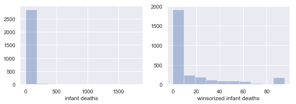

```
For column winsorized infant deaths...
Number of outliers (up-side) is: 0 at threshold 3
Number of outliers (down-side) is: 0 at threshold 3
```

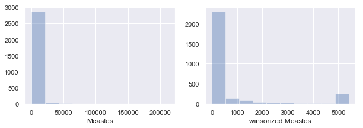

```
For column winsorized Measles...
Number of outliers (up-side) is: 0 at threshold 3
Number of outliers (down-side) is: 0 at threshold 3
```

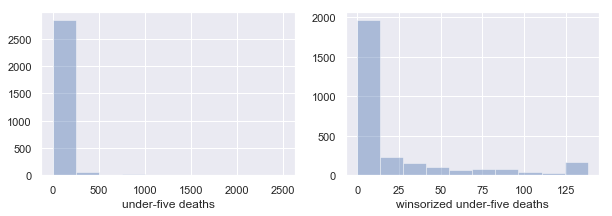

```
For column winsorized under-five deaths...
Number of outliers (up-side) is: 0 at threshold 3
Number of outliers (down-side) is: 0 at threshold 3
```

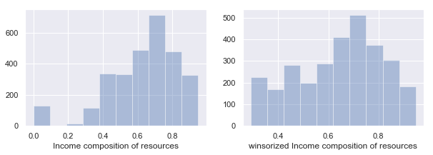

```
For column winsorized Income composition of resources...
Number of outliers (up-side) is: 0 at threshold 3
Number of outliers (down-side) is: 0 at threshold 3
```

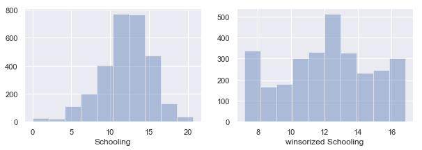

```
For column winsorized Schooling...
Number of outliers (up-side) is: 0 at threshold 3
Number of outliers (down-side) is: 0 at threshold 3
```

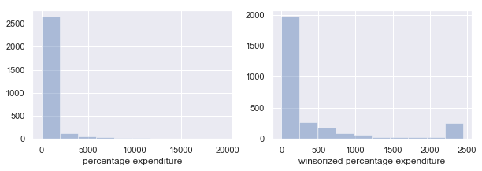

```
For column winsorized percentage expenditure...
Number of outliers (up-side) is: 0 at threshold 3
Number of outliers (down-side) is: 0 at threshold 3
```

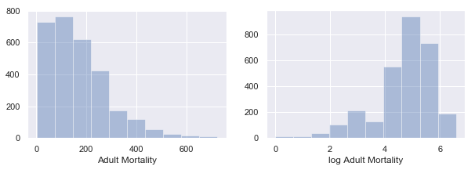

```
For column log Adult Mortality...
Number of outliers (up-side) is: 0 at threshold 3
Number of outliers (down-side) is: 30 at threshold 3
```

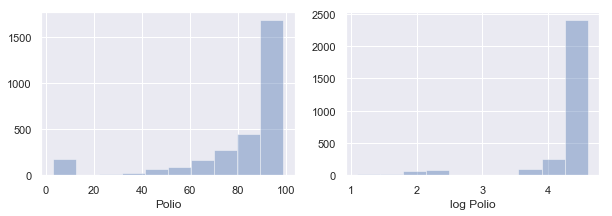

```
For column log Polio...
Number of outliers (up-side) is: 0 at threshold 3
Number of outliers (down-side) is: 178 at threshold 3
```

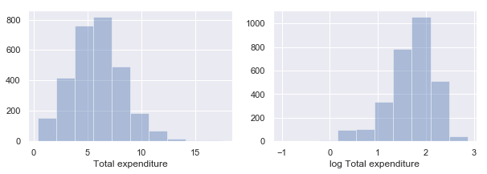

```
For column log Total expenditure...
Number of outliers (up-side) is: 0 at threshold 3
Number of outliers (down-side) is: 33 at threshold 3
```

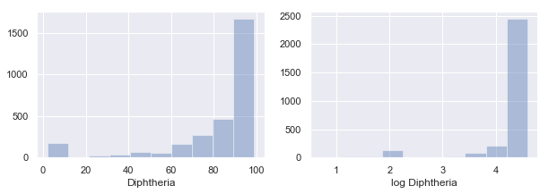

```
For column log Diphtheria...
Number of outliers (up-side) is: 0 at threshold 3
Number of outliers (down-side) is: 176 at threshold 3
```

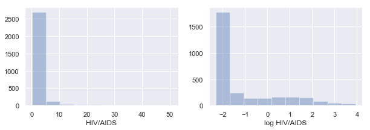

```
For column log HIV/AIDS...
Number of outliers (up-side) is: 13 at threshold 3
Number of outliers (down-side) is: 0 at threshold 3
```

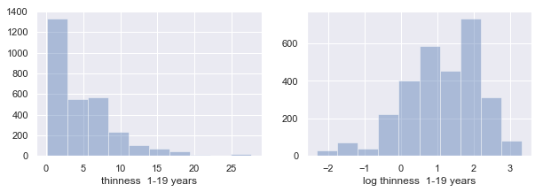

```
For column log thinness  1-19 years...
Number of outliers (up-side) is: 0 at threshold 3
Number of outliers (down-side) is: 28 at threshold 3
```

[1 more figures not shown]

```
For column log thinness 5-9 years...
Number of outliers (up-side) is: 0 at threshold 3
Number of outliers (down-side) is: 37 at threshold 3
```

```python
#manage outliers↔
```

```python
#describe of cleaned data↔
```

|  | Year | Life expectancy | Adult Mortality | infant deaths | Alcohol | percentage expenditure | Hepatitis B | Measles | BMI | under-five deaths | ... | winsorized Income composition of resources | winsorized Schooling | winsorized percentage expenditure | log Adult Mortality | log Polio | log Total expenditure | log Diphtheria | log HIV/AIDS | log thinness 1-19 years | log thinness 5-9 years |
| --- | --- | --- | --- | --- | --- | --- | --- | --- | --- | --- | --- | --- | --- | --- | --- | --- | --- | --- | --- | --- | --- |
| count | 2938.000000 | 2938.000000 | 2938.000000 | 2938.000000 | 2938.00000 | 2938.000000 | 2938.000000 | 2938.000000 | 2938.000000 | 2938.000000 | ... | 2938.000000 | 2938.000000 | 2938.000000 | 2938.000000 | 2938.000000 | 2938.000000 | 2938.000000 | 2938.000000 | 2938.000000 | 2938.000000 |
| mean | 2007.518720 | 69.231777 | 164.741882 | 30.303948 | 4.60024 | 738.251295 | 75.832054 | 2419.592240 | 38.323713 | 42.035739 | ... | 0.640659 | 12.112604 | 422.277005 | 4.708887 | 4.299985 | 1.679507 | 4.294785 | -1.221949 | 1.134315 | 1.122592 |
| std | 4.613841 | 9.508362 | 124.083816 | 117.926501 | 4.02767 | 1987.914858 | 27.928179 | 11467.272489 | 19.929396 | 160.445548 | ... | 0.171622 | 2.740865 | 727.354537 | 1.072238 | 0.624129 | 0.476577 | 0.629096 | 1.613377 | 1.038579 | 1.071781 |
| min | 2000.000000 | 36.300000 | 1.000000 | 0.000000 | 0.01000 | 0.000000 | 1.000000 | 0.000000 | 1.000000 | 0.000000 | ... | 0.291000 | 7.200000 | 0.000000 | 0.000000 | 1.098612 | -0.994252 | 0.693147 | -2.302585 | -2.302585 | -2.302585 |
| 25% | 2004.000000 | 63.200000 | 74.000000 | 0.000000 | 0.93000 | 4.685343 | 67.000000 | 0.000000 | 19.400000 | 0.000000 | ... | 0.504250 | 10.300000 | 4.685343 | 4.304065 | 4.343805 | 1.453953 | 4.356709 | -2.302585 | 0.470004 | 0.470004 |
| 50% | 2008.000000 | 72.000000 | 144.000000 | 3.000000 | 3.77500 | 64.912906 | 88.000000 | 17.000000 | 43.000000 | 4.000000 | ... | 0.673000 | 12.300000 | 64.912906 | 4.969813 | 4.532599 | 1.750937 | 4.532599 | -2.302585 | 1.223775 | 1.223775 |
| 75% | 2012.000000 | 75.600000 | 227.000000 | 22.000000 | 7.67750 | 441.534144 | 96.000000 | 360.250000 | 56.100000 | 28.000000 | ... | 0.772000 | 14.100000 | 441.534144 | 5.424950 | 4.574711 | 2.005526 | 4.574711 | -0.223144 | 1.960095 | 1.974081 |
| max | 2015.000000 | 89.000000 | 723.000000 | 1800.000000 | 17.87000 | 19479.911610 | 99.000000 | 212183.000000 | 87.300000 | 2500.000000 | ... | 0.948000 | 16.800000 | 2443.444275 | 6.583409 | 4.595120 | 2.867899 | 4.595120 | 3.923952 | 3.321432 | 3.353407 |

8 rows × 31 columns

```python
#example rows↔
```

|  | Country | Year | Status | Life expectancy | Adult Mortality | infant deaths | Alcohol | percentage expenditure | Hepatitis B | Measles | ... | winsorized Income composition of resources | winsorized Schooling | winsorized percentage expenditure | log Adult Mortality | log Polio | log Total expenditure | log Diphtheria | log HIV/AIDS | log thinness 1-19 years | log thinness 5-9 years |
| --- | --- | --- | --- | --- | --- | --- | --- | --- | --- | --- | --- | --- | --- | --- | --- | --- | --- | --- | --- | --- | --- |
| 0 | Afghanistan | 2015 | Developing | 65.0 | 263.0 | 62.0 | 0.01 | 71.279624 | 65.0 | 1154.0 | ... | 0.479 | 10.1 | 71.279624 | 5.572154 | 1.791759 | 2.099244 | 4.174387 | -2.302585 | 2.844909 | 2.850707 |
| 1 | Afghanistan | 2014 | Developing | 59.9 | 271.0 | 64.0 | 0.01 | 73.523582 | 62.0 | 492.0 | ... | 0.476 | 10.0 | 73.523582 | 5.602119 | 4.060443 | 2.101692 | 4.127134 | -2.302585 | 2.862201 | 2.862201 |
| 2 | Afghanistan | 2013 | Developing | 59.9 | 268.0 | 66.0 | 0.01 | 73.219243 | 64.0 | 430.0 | ... | 0.470 | 9.9 | 73.219243 | 5.590987 | 4.127134 | 2.095561 | 4.158883 | -2.302585 | 2.873565 | 2.873565 |
| 3 | Afghanistan | 2012 | Developing | 59.5 | 272.0 | 69.0 | 0.01 | 78.184215 | 67.0 | 2787.0 | ... | 0.463 | 9.8 | 78.184215 | 5.605802 | 4.204693 | 2.142416 | 4.204693 | -2.302585 | 2.884801 | 2.890372 |
| 4 | Afghanistan | 2011 | Developing | 59.2 | 275.0 | 71.0 | 0.01 | 7.097109 | 68.0 | 3013.0 | ... | 0.454 | 9.5 | 7.097109 | 5.616771 | 4.219508 | 2.063058 | 4.219508 | -2.302585 | 2.901422 | 2.901422 |

5 rows × 33 columns

### Univariate Analysis

The distributions of all of the variables are shown. Above (under data cleaning), find the distributions of transformed variables, alongside it's pre-transformed version.

Below find the distributions of variables that are not transformed.

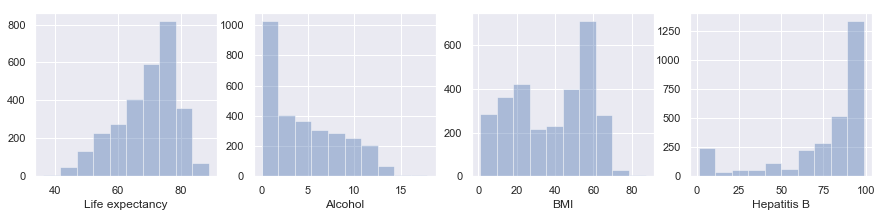

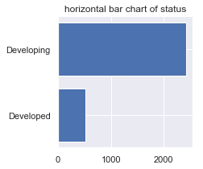

```python
#un-transformed variable distributions↔
```

### Bivariate analysis: Correlation with Life Expectancy

Categororical:

Status: The two levels of status (developing and developed) have different mean life expectancies that are stasticially significant at p <0.05.

Continuous:

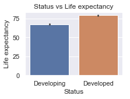

```
t-test between groups Developing and Developed is significant:  p = 1.778895704879565e-170:
```

```python
#life-expectancy by country status↔
```